# Bike Ride Analysis Report

Joanna Nana Ama Kwame

2023-03-07

## Introduction

> Welcome to our Bike Ride Analysis Report, where we share the riding habits of Cyclistic’s two classes of riders: casual and members(annual subscribers)

> The goal was to investigate how our casual and member riders differ in their bike rides. This is to help the marketing team determine how to convert casual riders to members to grow the company.

## Data Cleaning And Analysis

> We load and clean the data in Rstudio using R code, then We analyze the data to gain insights into the differences between casual riders and annual members.

### Check out the process we went through to clean and analyze the data [here](https://sethmegbetor.github.io/JoannaCode/index.html).

## Findings

> Over a one year period; April 2019 to March 2020, Cyclistic recorded almost 4million rides,specifically 3,870,187. Our analysis revealed that members ride more frequently than casual riders. Take a look at the plot below, which compares the number of rides taken by members and casual riders over the course of a year:

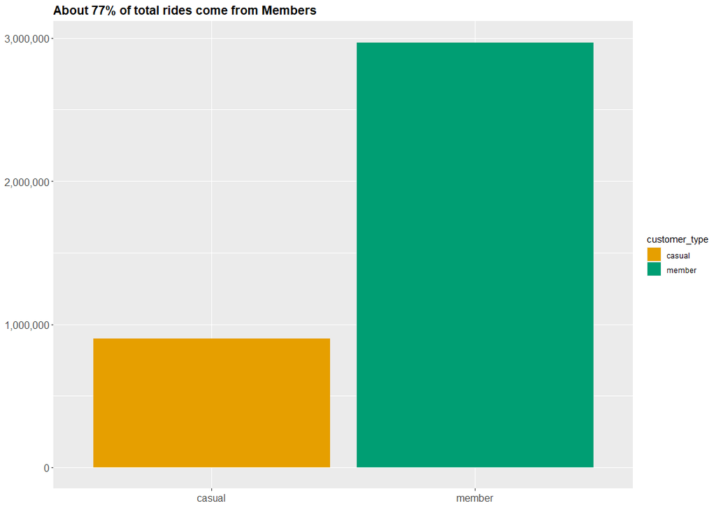

> *As seen, our members accounted for 77% of the rides*.

> Now that we have a better understanding of the distribution of rides between members and casual riders, let’s take a closer look at how these rides are spread over time. Specifically, we examined the frequency of rides by day of the week, week of the year, and month of the year, to identify any patterns in their ride behavior.

> Let’s see weekly ride totals over the 53 weeks, followed by a corresponding weekly ride length in minutes.

[figure not shown]

> Despite the overall volatility of the trend, some general patterns can be discerned;
> - Around week 20 to 45 when we see a sharp increase in ride frequency, there is a corresponding sharp increase in ride lengths. See weekly ride length visualisation below;

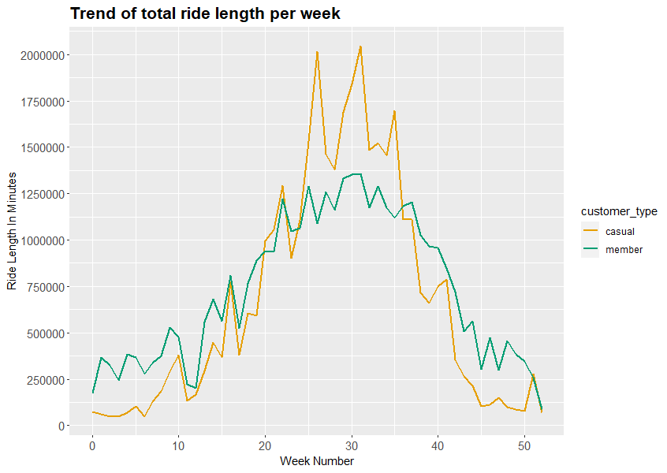

### Let’s begin with period 1(April 1, 2019 to July 29, 2019)

> In the first period,casual riders took an average of 3,539 rides daily, while members took almost triple that amount with an average of 9,987 rides.

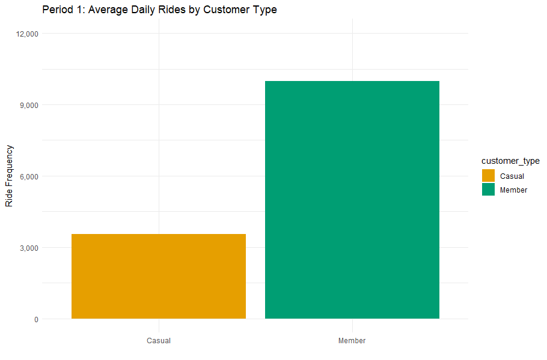

and on average, casual riders spent 40 minutes on a ride, while members spent 14 minutes.

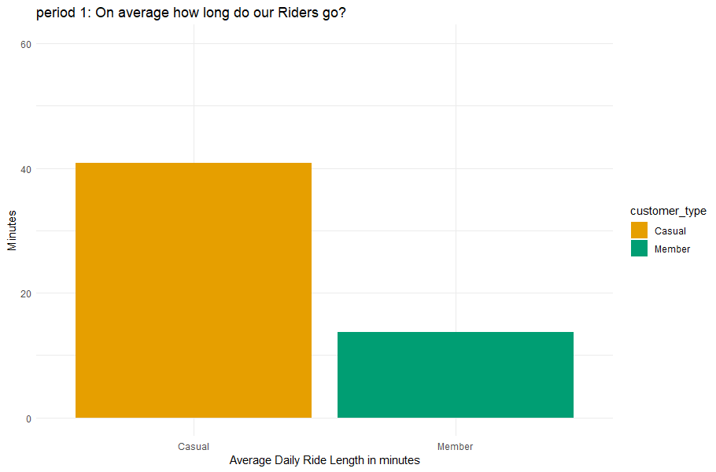

### Moving on to the second period,(July 30, 2019 to January 21, 2020);

> casual riders took an average of 2,483 rides daily and members took 8,440 rides.

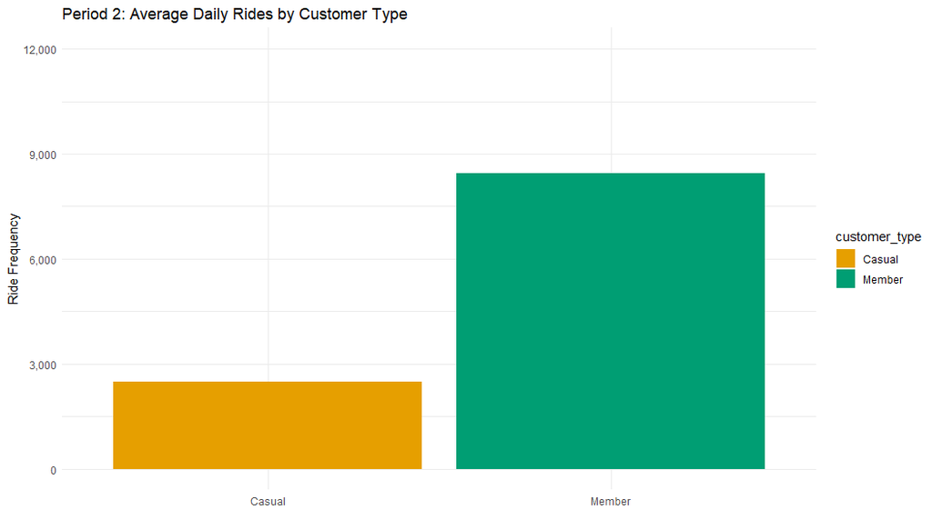

The average ride length for casual riders decreased slightly to 38 minutes, while members spent an average of 12 minutes on a ride.

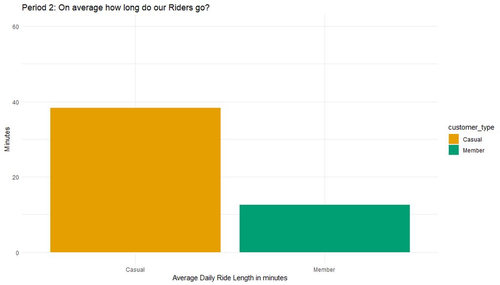

### Finally, in the third period (January 22, 2020 to March 31, 2020);

> the average ride frequency for both casual and member riders decreased significantly, with casual riders taking an average of 553 rides and members taking 4081 rides.

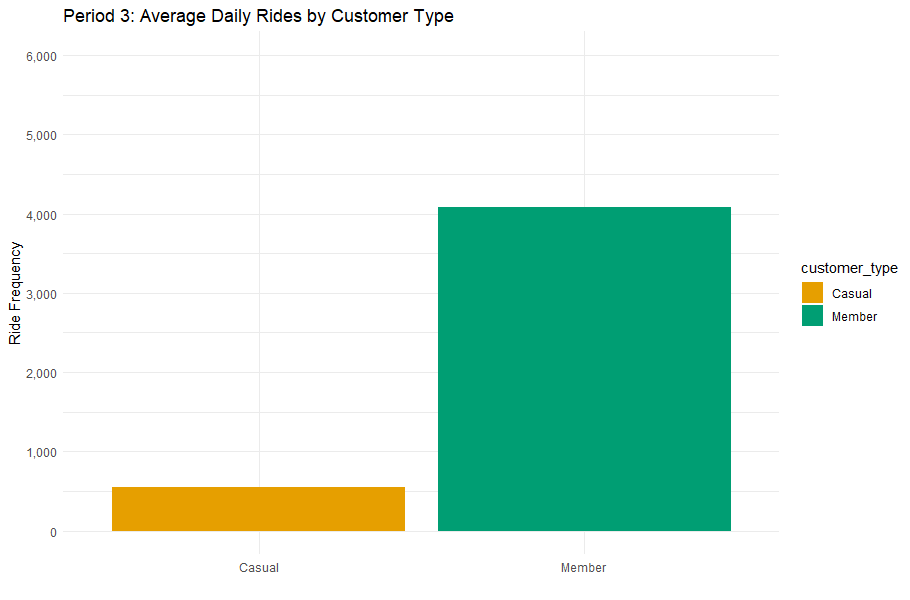

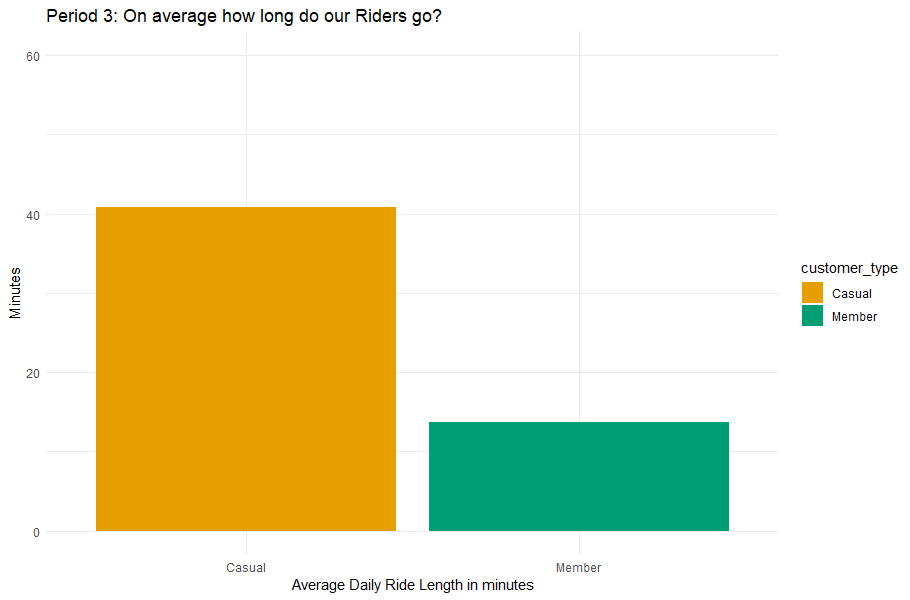

Overall, the data suggests that members take more rides and spend less time on each ride while casual riders take less rides but spend more time on each ride.

### What About Days Of The Week?

> Well, Cyclistic’s two classes of customers both show up on everyday of the week. We observed that on weekdays, rides are fairly evenly distributed for both members and casuals,both classes of riders seem to have a similar pattern of usage on weekdays.

> However, things change over the weekends. We noticed a decrease in the number of rides taken by members, and an increase in that of riders. This suggests that our casual riders may be using Cyclistic for weekend leisure activities, while our members may be utilizing our service mainly for weekday commuting. See this behavior in the chart below;

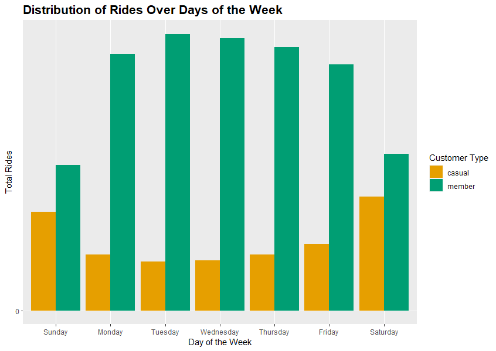

### Okay, so we should expect more of our casual riders on weekends right? What time of the day?

> When we look at the distribution of rides over different times of the day, we see a clear pattern. This pattern is consistent for both casual and member riders.

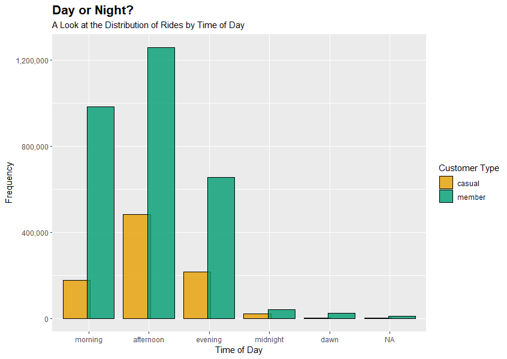

> Is the time of day behavior shown above true for each day of the week? Yes;

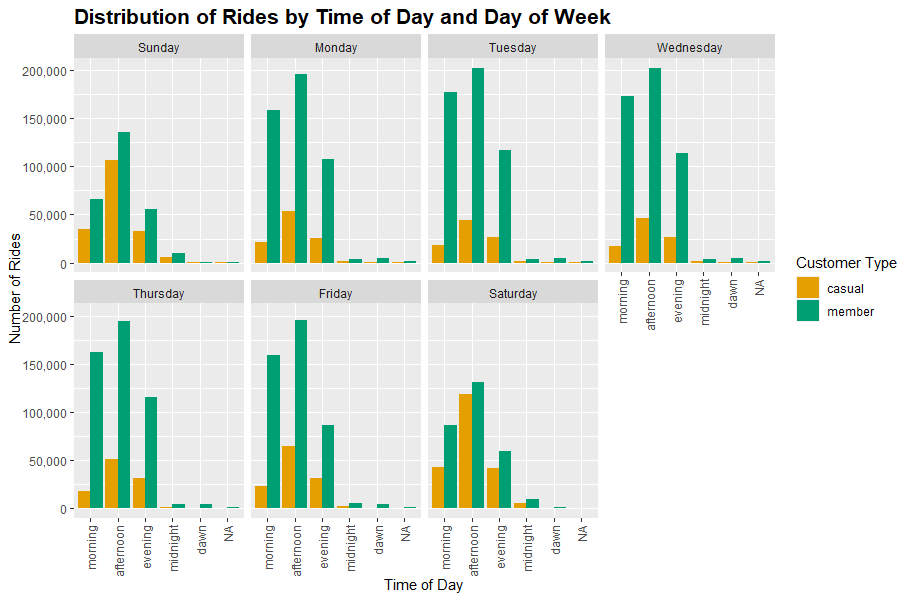

> Finally, let’s take a look at the top 5 popular start and end stations for our riders in a descending order.

> We found that the top 5 popular start stations for our casual riders are:

> 1.Streeter Dr & Grand Ave

> 2.Lake Shore Dr & Monroe St

> 3.Millennium Park

> 4.Michigan Ave & Oak St

> 5.Shedd Aquarium

> On the other hand, for members, the top 5 popular start stations are:

> 1.Canal St & Adams St

> 2.Clinton St & Madison St

> 3.Clinton St & Washington Blvd

> 4.Columbus Dr & Randolph St

> 5.Franklin St & Monroe St

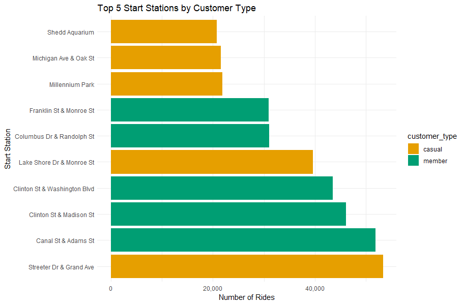

> Now unto the top 5 stations where both classes of our riders end their rides,also listed in a descending order.

> For casual riders, the top 5 popular end stations are:

> 1.Streeter Dr & Grand Ave

> 2.Lake Shore Dr & Monroe St

> 3.Millennium Park

> 4.Michigan Ave & Oak St

> 5.Lake Shore Dr & North Blvd

> > For members, the top 5 popular end stations are;

> 1.Canal St & Adams St

> 2.Clinton St & Washington Blvd

> 3.Clinton St & Madison St

> 4.Daley Center Plaza

> 5.Kingsbury St & Kinzie St

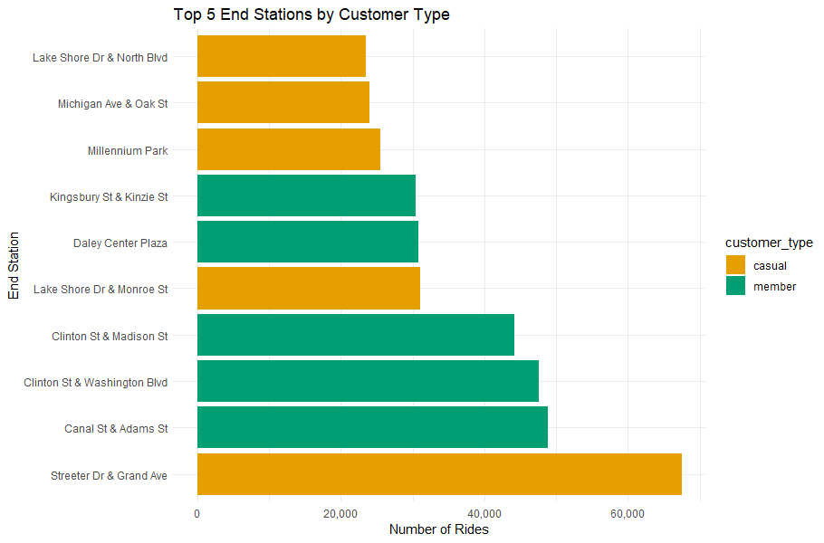

This findings suggest that casual riders tend to start and end their rides near popular tourist spots, while members tend to start and end their rides near business districts and transportation hubs.

### Conclusion

> Based on our findings, it is evident that members take more rides and spend less time on each ride, while casual riders take fewer rides but spend more time on each ride. We saw that on weekdays, rides are fairly evenly distributed for both members and casuals, but on weekends, we see an increase in the number of rides taken by casual riders and a decrease for members.

> It appears our members mostly use our bikes for commuting to work while our casuals mostly ride for leisure and pleasure.

### Recommendations

> 1.Cyclistic should promote the benefits of membership, such as access to more bikes, priority service, and the ability to reserve bikes in advance.

> 2.Cyclistic could also consider offering incentives to encourage casual riders to become members, such as discounts on annual subscriptions or rewards for frequent riders.